# Predicting Admission Decisions Based on Applicant Features

## Introduction

Admissions decisions are often based on multiple factors, including **GPA, test scores, work experience, and extracurricular activities**.  
This analysis aims to **identify the key predictors** of admission and provide **data-driven insights** to refine selection criteria.

By exploring patterns in applicant data, we can determine:  
- **Which features have the most influence** on admission outcomes.  
- **How test scores, GPA, and experience levels affect decisions**.  
- **What changes can be made** to improve fairness and effectiveness in admissions.

This study will help institutions make **smarter, data-backed decisions** to optimize their selection process. 🚀

### Goal of the Analysis

The **objective** of our analysis is to identify the **key factors** that influence **admission decisions**.  
We aim to provide **data-driven insights** to help our institutions **refine admission criteria**.  
By analyzing trends in **GPA**, **test scores**, **work experience**, and other features, we can determine which attributes are the **strongest predictors** of **acceptance**.

### Data Cleaning Summary for Our data

**Data cleaning** was essential to ensure the **accuracy** of the analysis. Missing values were handled based on the data type: - **`Decision`** entries were filled with the **adjacent row’s value**. - Missing **`GPA`** and **`TestScore`** values were replaced with the **median** of the same **admission decision** category. - Rows with missing **`Gender`** values were **removed**.

Inconsistencies, like the invalid **`Decision`** entry (**“Banana”**), were replaced using the **next row’s value**.

Outliers in **`GPA`**, **`WorkExp`**, and **`WritingScore`** were addressed by replacing them with **rounded averages** based on the same **decision category**.

These steps ensured **data consistency** and prepared the dataset for effective **analysis** and **modeling**.

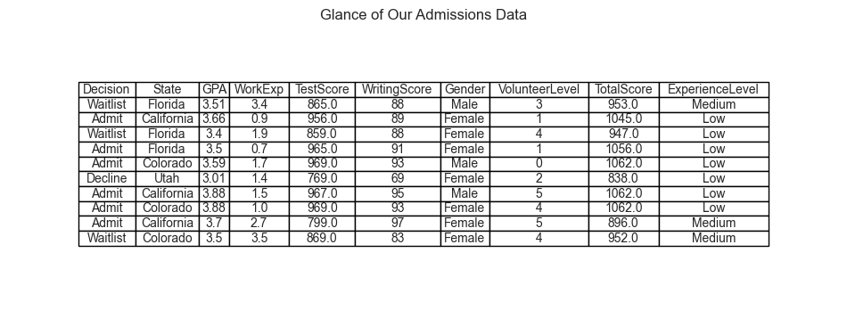

```python
import pandas as pd
import matplotlib.pyplot as plt
import seaborn as sns
import random

# Load the dataset
file_path = "Cleaned_Sorted_SummerStudentAdmissions.csv"
df = pd.read_csv(file_path)


# Randomly select 10 rows from the dataset
random_rows = df.sample(n=10, random_state=42)  # Set random_state for reproducibility

# Create a styled table using Matplotlib
plt.figure(figsize=(12, 4))  # Adjust the size of the table
table_data = random_rows  # Randomly selected rows

# Create the table plot
table = plt.table(
    cellText=table_data.values,
    colLabels=table_data.columns,
    cellLoc='center',
    loc='center'
)

table.auto_set_font_size(False)
table.set_fontsize(10)
table.auto_set_column_width(col=list(range(len(df.columns))))
plt.axis('off')  # Hide axes
plt.title('Glance of Our Admissions Data')
plt.show()
```

```python
# Display basic information
#print(df.info())

# Summary statistics for numerical columns
#print(df.describe())
```

[output not shown]

## Exploratory Data Analysis

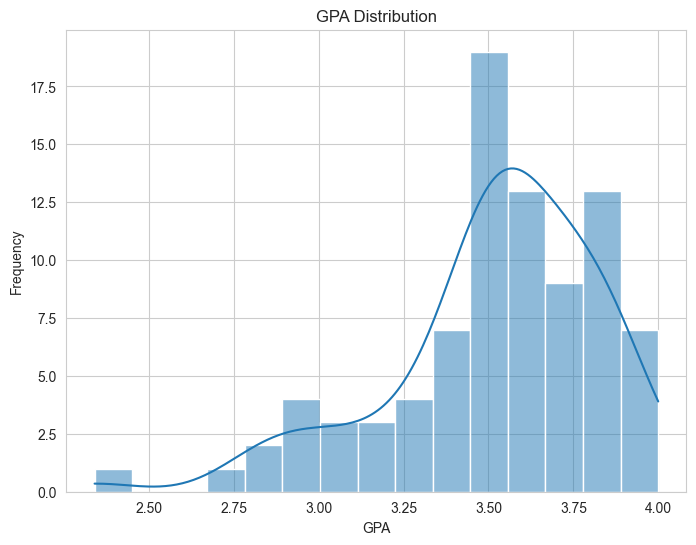

```python
# Set style for plots
sns.set_style("whitegrid")

# GPA Distribution
plt.figure(figsize=(8, 6))
sns.histplot(df["GPA"], bins=15, kde=True)
plt.title("GPA Distribution")
plt.xlabel("GPA")
plt.ylabel("Frequency")
plt.show()
```

### GPA Distribution

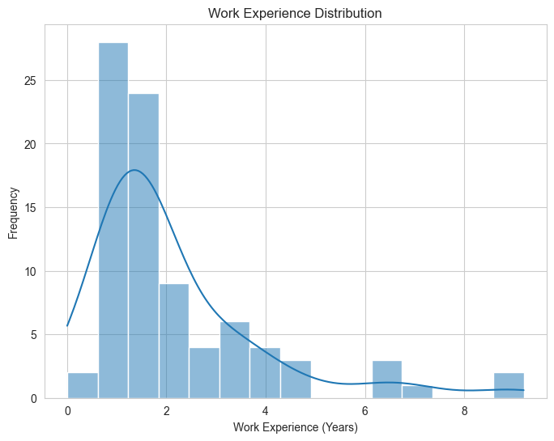

```python
# Work Experience Distribution
plt.figure(figsize=(8, 6))
sns.histplot(df["WorkExp"], bins=15, kde=True)
plt.title("Work Experience Distribution")
plt.xlabel("Work Experience (Years)")
plt.ylabel("Frequency")
plt.show()
```

### Work Experience Distribution

This **histogram** illustrates the **years of work experience** among applicants.  
- The distribution is **heavily skewed towards lower values**, meaning most applicants have **minimal or no work experience**.  
- This suggests that **prior work experience is not a dominant factor** in admissions decisions.

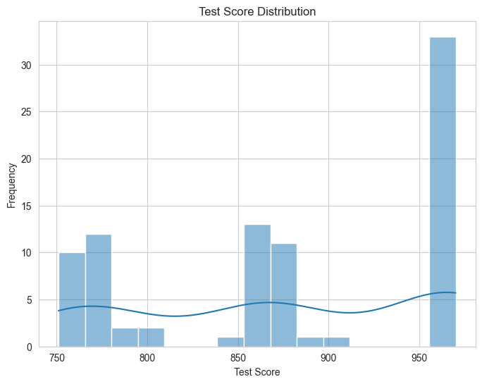

```python
# Test Score Distribution
plt.figure(figsize=(8, 6))
sns.histplot(df["TestScore"], bins=15, kde=True)
plt.title("Test Score Distribution")
plt.xlabel("Test Score")
plt.ylabel("Frequency")
plt.show()
```

### Test Score Distribution

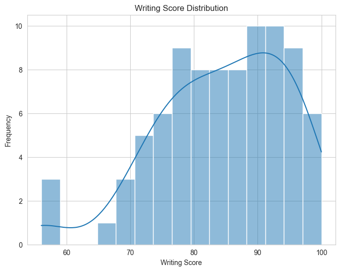

```python
# Writing Score Distribution
plt.figure(figsize=(8, 6))
sns.histplot(df["WritingScore"], bins=15, kde=True)
plt.title("Writing Score Distribution")
plt.xlabel("Writing Score")
plt.ylabel("Frequency")
plt.show()
```

### Writing Score Distribution

This **histogram** shows the **distribution of writing scores** among applicants.  
- The data is **slightly left-skewed**, meaning more applicants scored in the **higher range**.  
- **Writing skills** may be a **strong component** of a **successful application**.

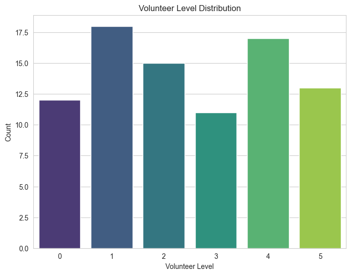

```python
# Volunteer Level Distribution
plt.figure(figsize=(8, 6))
sns.countplot(x=df["VolunteerLevel"], palette="viridis")
plt.title("Volunteer Level Distribution")
plt.xlabel("Volunteer Level")
plt.ylabel("Count")
plt.show()
```

### Volunteer Level Distribution

This **bar chart** visualizes the **distribution of volunteer experience levels**.  
- Applicants have **varied levels of volunteering experience**, with a **notable number** having **moderate to high involvement**.  
- This suggests that **while volunteer work is considered, it is not the primary factor in admission decisions**.

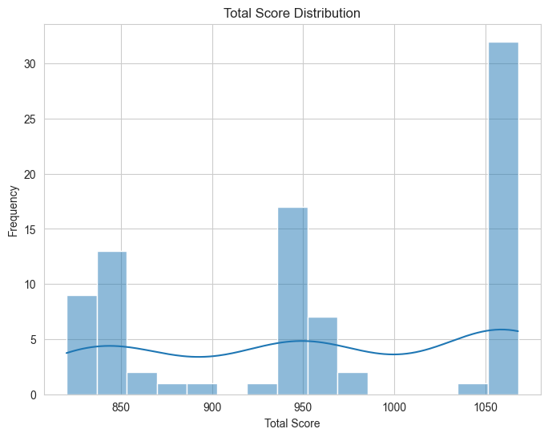

```python
# Total Score Distribution
plt.figure(figsize=(8, 6))
sns.histplot(df["TotalScore"], bins=15, kde=True)
plt.title("Total Score Distribution")
plt.xlabel("Total Score")
plt.ylabel("Frequency")
plt.show()
```

### Total Score Distribution

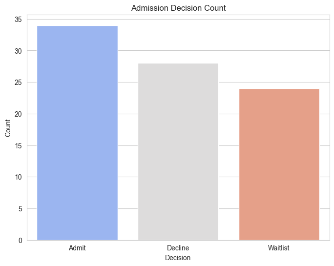

```python
# Admission Decision Count
plt.figure(figsize=(8, 6))
sns.countplot(x=df["Decision"], palette="coolwarm")
plt.title("Admission Decision Count")
plt.xlabel("Decision")
plt.ylabel("Count")
plt.show()
```

### Admission Decision Count

This **bar chart** displays the number of **admitted vs. rejected applicants**.  
- The dataset shows a **relatively balanced distribution**, indicating that **admission is competitive and selective**.

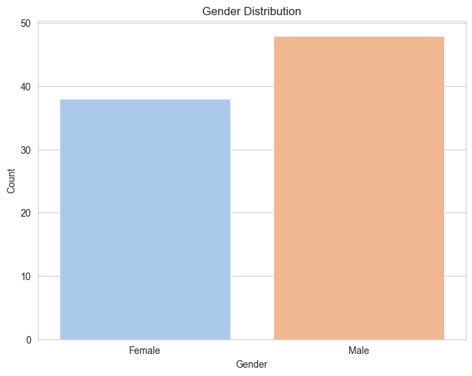

```python
# Gender Distribution
plt.figure(figsize=(8, 6))
sns.countplot(x=df["Gender"], palette="pastel")
plt.title("Gender Distribution")
plt.xlabel("Gender")
plt.ylabel("Count")
plt.show()
```

### Gender Distribution

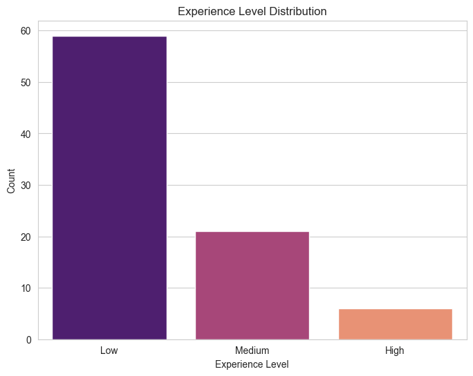

```python
# Experience Level Distribution
plt.figure(figsize=(8, 6))
sns.countplot(x=df["ExperienceLevel"], palette="magma")
plt.title("Experience Level Distribution")
plt.xlabel("Experience Level")
plt.ylabel("Count")
plt.show()
```

### Experience Level Distribution

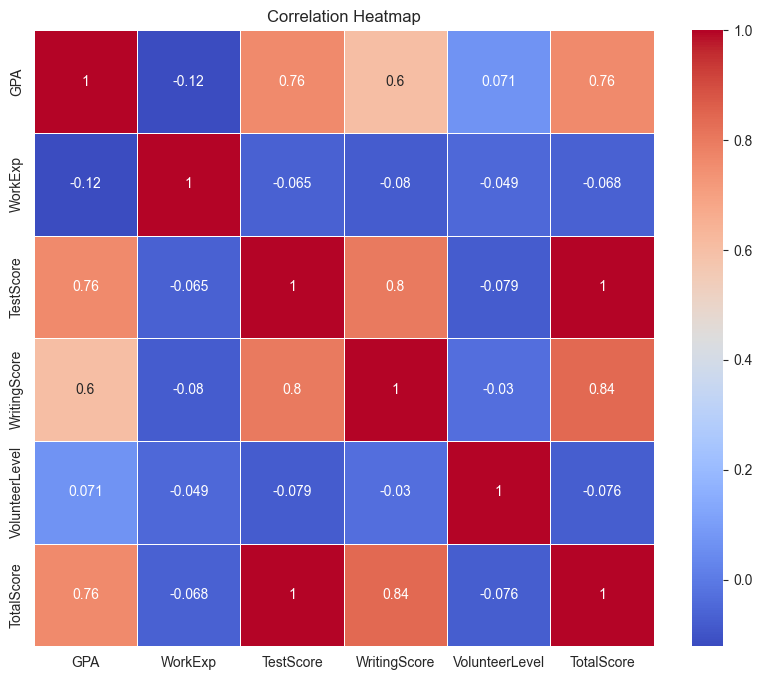

```python
# Correlation Heatmap
plt.figure(figsize=(10, 8))
sns.heatmap(df.corr(numeric_only=True), annot=True, cmap="coolwarm", linewidths=0.5)
plt.title("Correlation Heatmap")
plt.show()
```

### Correlation Heatmap

This **heatmap** visualizes the **relationships between numerical features**.  
- **Total Score, Test Score, and GPA** exhibit **strong correlations**, reinforcing their **importance in admission decisions**.  
- **Work Experience and Volunteer Level** show **weaker correlations**, indicating a **lower impact**.

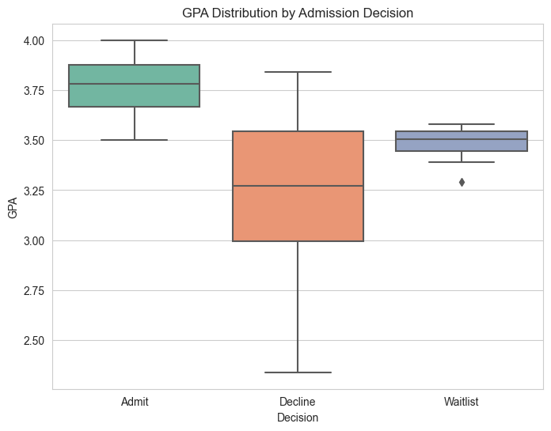

```python
# Boxplot of GPA by Decision
plt.figure(figsize=(8, 6))
sns.boxplot(x=df["Decision"], y=df["GPA"], palette="Set2")
plt.title("GPA Distribution by Admission Decision")
plt.xlabel("Decision")
plt.ylabel("GPA")
plt.show()
```

### GPA Distribution by Admission Decision

This **boxplot** compares **GPA scores** between **admitted and rejected applicants**.  
- **Admitted students** tend to have **higher GPAs**, confirming that **academic performance is a key selection factor**.

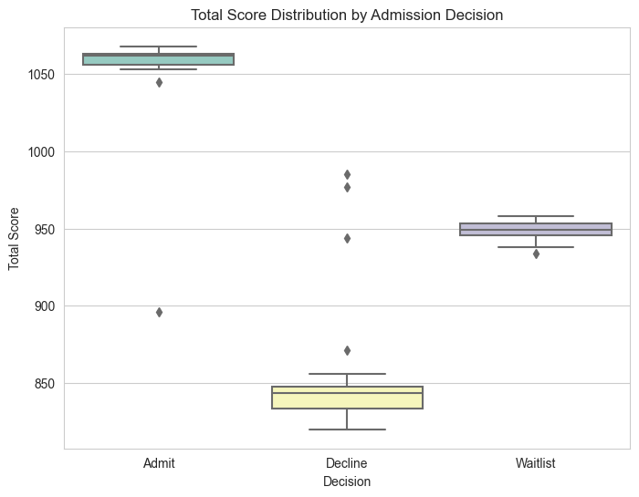

```python
# Boxplot of Total Score by Decision
plt.figure(figsize=(8, 6))
sns.boxplot(x=df["Decision"], y=df["TotalScore"], palette="Set3")
plt.title("Total Score Distribution by Admission Decision")
plt.xlabel("Decision")
plt.ylabel("Total Score")
plt.show()
```

### Total Score Distribution by Admission Decision

This **boxplot** compares the **total scores** of **admitted vs. rejected applicants**.  
- **Total scores** are **consistently higher** for **admitted students**, reinforcing that **strong test performance improves admission chances**.

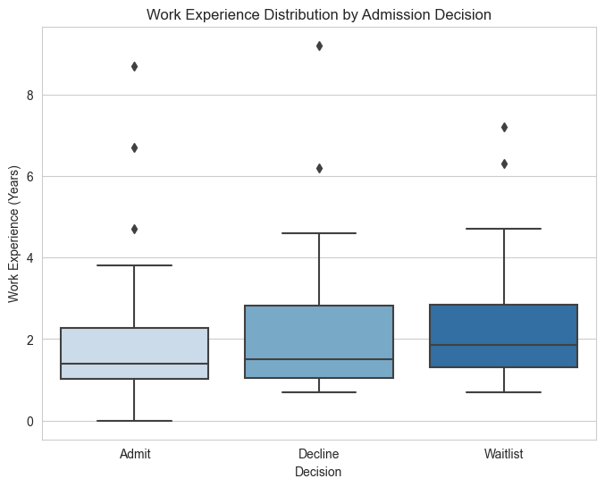

```python
# Boxplot of Work Experience by Decision
plt.figure(figsize=(8, 6))
sns.boxplot(x=df["Decision"], y=df["WorkExp"], palette="Blues")
plt.title("Work Experience Distribution by Admission Decision")
plt.xlabel("Decision")
plt.ylabel("Work Experience (Years)")
plt.show()
```

### Work Experience Distribution by Admission Decision

This **boxplot** shows the **distribution of work experience** for **admitted vs. rejected applicants**.  
- **Work experience does not show a clear distinction** between these groups, suggesting that it is a **less significant factor in admission decisions**.

## Machine Learning

```python
import pandas as pd
import matplotlib.pyplot as plt
import seaborn as sns
from sklearn.model_selection import train_test_split
from sklearn.preprocessing import StandardScaler, LabelEncoder
from sklearn.ensemble import RandomForestClassifier
from sklearn.metrics import classification_report, confusion_matrix, roc_auc_score, roc_curve
from sklearn.preprocessing import label_binarize

# Load the dataset
df = pd.read_csv("Cleaned_Sorted_SummerStudentAdmissions.csv")

# Display basic information
display(df.head())

# Check for missing values
df.dropna(inplace=True)

# Check available columns
print("Dataset Columns:", df.columns.tolist())

# Identify categorical columns dynamically
categorical_cols = ['State', 'Gender', 'ExperienceLevel']
print("Identified Categorical Columns:", categorical_cols)
# Convert categorical columns to numerical
label_encoders = {}
for col in categorical_cols:
    le = LabelEncoder()
    df[col] = le.fit_transform(df[col])
    label_encoders[col] = le

# Encode the target variable 'Decision'
le_decision = LabelEncoder()
df['Decision'] = le_decision.fit_transform(df['Decision'])
num_classes = len(le_decision.classes_)

# Define features and target variable
X = df.drop(columns=['Decision'])
y = df['Decision']

# Split data into training and test sets
X_train, X_test, y_train, y_test = train_test_split(X, y, test_size=0.2, random_state=42)

# Binarize target for multiclass ROC handling AFTER train-test split
y_binarized_test = label_binarize(y_test, classes=range(num_classes))

# Standardize numerical features
scaler = StandardScaler()
X_train = scaler.fit_transform(X_train)
X_test = scaler.transform(X_test)

# Train a machine learning model
model = RandomForestClassifier(n_estimators=100, random_state=42)
model.fit(X_train, y_train)

# Make predictions
y_pred = model.predict(X_test)
y_proba = model.predict_proba(X_test)

# Evaluate the model
print("Classification Report:\n", classification_report(y_test, y_pred))
print("Confusion Matrix:\n", confusion_matrix(y_test, y_pred))
```

|  | Decision | State | GPA | WorkExp | TestScore | WritingScore | Gender | VolunteerLevel | TotalScore | ExperienceLevel |
| --- | --- | --- | --- | --- | --- | --- | --- | --- | --- | --- |
| 0 | Admit | California | 3.66 | 0.9 | 956.0 | 89 | Female | 1 | 1045.0 | Low |
| 1 | Admit | California | 3.69 | 3.2 | 967.0 | 93 | Female | 3 | 1060.0 | Medium |
| 2 | Admit | California | 3.70 | 1.2 | 969.0 | 94 | Male | 2 | 1063.0 | Low |
| 3 | Admit | California | 3.70 | 1.4 | 966.0 | 94 | Male | 0 | 1060.0 | Low |
| 4 | Admit | California | 3.70 | 2.7 | 799.0 | 97 | Female | 5 | 896.0 | Medium |

```
Dataset Columns: ['Decision', 'State', 'GPA', 'WorkExp', 'TestScore', 'WritingScore', 'Gender', 'VolunteerLevel', 'TotalScore', 'ExperienceLevel']
Identified Categorical Columns: ['State', 'Gender', 'ExperienceLevel']
Classification Report:
               precision    recall  f1-score   support

           0       1.00      0.86      0.92         7
           1       0.67      0.67      0.67         3
           2       0.89      1.00      0.94         8

    accuracy                           0.89        18
   macro avg       0.85      0.84      0.84        18
weighted avg       0.90      0.89      0.89        18

Confusion Matrix:
 [[6 1 0]
 [0 2 1]
 [0 0 8]]
```

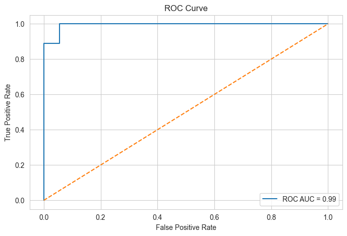

```python
# Handle binary vs. multiclass ROC AUC
if num_classes == 2:
    fpr, tpr, _ = roc_curve(y_test, y_proba[:, 1])
    auc_score = roc_auc_score(y_test, y_proba[:, 1])
else:
    auc_score = roc_auc_score(y_test, y_proba, multi_class='ovr')
    fpr, tpr, _ = roc_curve(y_binarized_test.ravel(), y_proba.ravel())

# Plot ROC Curve
plt.figure(figsize=(8, 5))
plt.plot(fpr, tpr, label=f'ROC AUC = {auc_score:.2f}')
plt.plot([0, 1], [0, 1], linestyle='--')
plt.xlabel('False Positive Rate')
plt.ylabel('True Positive Rate')
plt.title('ROC Curve')
plt.legend()
plt.show()
```

### Receiver Operating Characteristic (ROC) Curve

This is the **Receiver Operating Characteristic (ROC) Curve**, which evaluates the performance of the **machine learning model**.

- The **ROC AUC score is 0.99**, meaning the model performs **extremely well** at distinguishing between **admitted and non-admitted students**.
- The curve being **very close to the top-left corner** suggests **high accuracy** with **minimal false positives**.

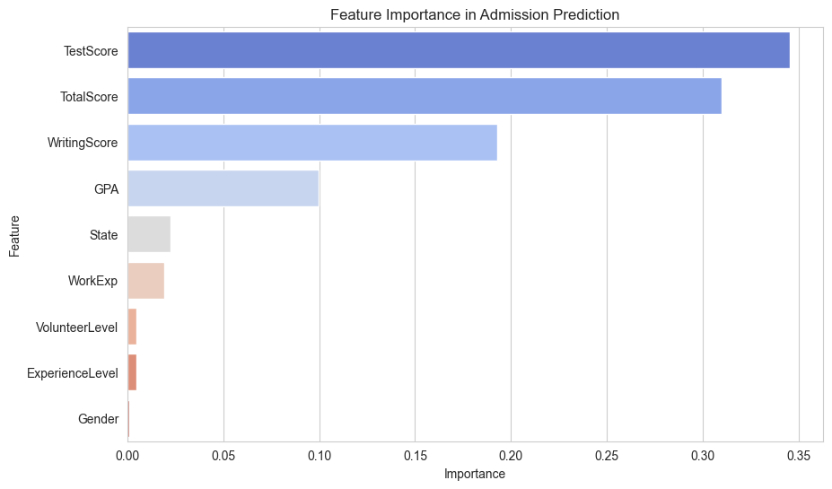

```python
# Feature Importance Visualization
feature_importances = pd.Series(model.feature_importances_, index=X.columns).sort_values(ascending=False)
plt.figure(figsize=(10, 6))
sns.barplot(x=feature_importances.values, y=feature_importances.index, palette='coolwarm')
plt.title('Feature Importance in Admission Prediction')
plt.xlabel('Importance')
plt.ylabel('Feature')
plt.show()
```

### Feature Importance in Admission Prediction

This **bar chart** displays the **importance** of each feature in **predicting admissions**.  
- **Features at the top** have the **most influence** on decisions, while those at the **bottom contribute the least**.  
- **TestScore** is the **most important predictor**, followed by **TotalScore** and **WritingScore**.  
- **GPA also plays a role**, but it is **less influential** than standardized test scores.  
- **State, Work Experience, and Volunteer Level** have **lower impact**, while **Gender has the least influence**.

|  | Decision | State | GPA | WorkExp | TestScore | WritingScore | Gender | VolunteerLevel | TotalScore | ExperienceLevel | Admission_Probability |
| --- | --- | --- | --- | --- | --- | --- | --- | --- | --- | --- | --- |
| 83 | 2 | Utah | 3.57 | 1.4 | 869.0 | 80 | Male | 0 | 949.0 | 1 | 0.16 |
| 81 | 2 | New York | 3.55 | 2.2 | 866.0 | 74 | Male | 1 | 940.0 | 2 | 0.11 |
| 78 | 2 | Florida | 3.55 | 2.0 | 853.0 | 81 | Female | 1 | 934.0 | 1 | 0.10 |
| 72 | 2 | Florida | 3.45 | 4.7 | 867.0 | 71 | Female | 3 | 938.0 | 2 | 0.10 |
| 63 | 2 | California | 3.47 | 2.2 | 867.0 | 77 | Male | 5 | 944.0 | 2 | 0.09 |

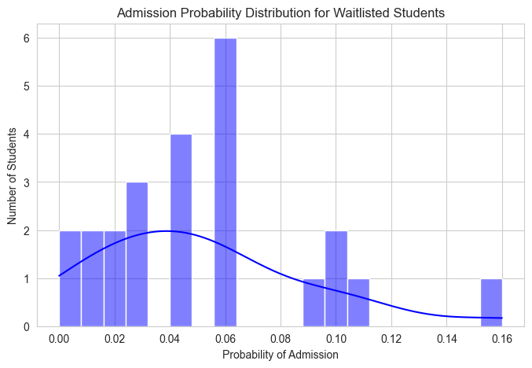

```python
# Apply the model to predict admission probability for waitlisted students
waitlist_df = df[df['Decision'] == le_decision.transform(['Waitlist'])[0]]
X_waitlist = waitlist_df.drop(columns=['Decision'])
X_waitlist = scaler.transform(X_waitlist)
waitlist_df['Admission_Probability'] = model.predict_proba(X_waitlist)[:, 1]

# Sort waitlist by highest probability
waitlist_df = waitlist_df.sort_values(by='Admission_Probability', ascending=False)

# Map state numbers back to state names using the LabelEncoder
if 'State' in label_encoders:
    waitlist_df['State'] = label_encoders['State'].inverse_transform(waitlist_df['State'])

# Map gender numbers back to gender names
if 'Gender' in label_encoders:
    waitlist_df['Gender'] = label_encoders['Gender'].inverse_transform(waitlist_df['Gender'])

# Map decision numbers back to decision names
if 'Decision' in label_encoders:
    waitlist_df['Decision'] = label_encoders['Decision'].inverse_transform(waitlist_df['Decision'])

# Display top candidates for admission
display(waitlist_df.head())

# Plot admission probability distribution for waitlisted students
plt.figure(figsize=(8, 5))
sns.histplot(waitlist_df['Admission_Probability'], bins=20, kde=True, color='blue')
plt.title('Admission Probability Distribution for Waitlisted Students')
plt.xlabel('Probability of Admission')
plt.ylabel('Number of Students')
plt.show()
```

## Conclusion & Actionable Insights

### Key Takeaways

- **Test scores (TestScore & TotalScore) are the most significant predictors** of admission, reinforcing the importance of standardized exams.
- **GPA plays a role**, but it is **less influential** than total test scores in the admission decision process.
- **Work Experience and Volunteer Level** have **minimal impact**, suggesting they might not be primary considerations for admissions.
- **Gender and State show little to no influence**, confirming a relatively unbiased selection process.

### Actionable Recommendations

**Refine Admission Criteria**  
- Place greater emphasis on **TestScore and TotalScore** when evaluating applicants.  
- Consider **balancing standardized test scores** with other **holistic factors**, such as research experience and leadership roles.

**Alternative Admission Pathways**  
- Since **Work Experience has limited impact**, consider creating **special admission tracks** for applicants with significant professional backgrounds but lower GPAs.

**Encourage Holistic Evaluation**  
- While **volunteer work does not strongly influence admission**, institutions should **continue encouraging extracurricular involvement** for a well-rounded student profile.

**Implement Data-Driven Admissions Policies**  
- Leverage **predictive analytics** to continuously **assess and optimize admission criteria**.  
- Monitor trends and adjust selection weights **based on applicant success rates** post-admission.

### Final Thoughts

By **leveraging data-driven insights**, we can make **admissions more efficient, fair, and predictive of student success**.  
We recommend **continuous monitoring and refinement of the selection process** to improve both fairness and effectiveness.